# Regressions

Johanna Mehler

2024-04-30

# 1 Data preparation

## 1.1 Libraries and read in data

```r
library(tidyverse)
library(here)
library(table1)
```

```r
library(ggplot2)
library(lmtest)
library(stargazer)
data <- read_csv(here("data/data_combined.csv"))
data <- read_csv(here("data", "data_combined.csv"),
                 col_types = cols(
                   academic_status = col_factor(levels = c("academic", "non-academic")),
                   educ_cat = col_factor(levels = c("Low", "Intermediate", "High")),
                   gender = col_factor(levels = c("Male", "Female")),
                   age_cat = col_factor(levels = c("18-29", "30-49", "50-69", "70+")),
                   polinterest = col_factor(levels = c("1", "2", "3", "4")),
                   polinterest_cat_3 = col_factor(levels = c("Low", "Intermediate", "High")),
                   minority = col_factor(levels = c("0", "1")),
                   minority_cat = col_factor(levels = c("Non-minority", "Minority")),
                   empathy_pc_cat = col_factor(levels = c("Less empathetic", "More empathetic")),
                   exp_hate_speech_cat = col_factor(levels = c("Less experience", "More experience")),
                   exp_hostile_engagement_cat = col_factor(levels = c("Less experience", "More experience")),
                   cluster = col_factor(levels = c("Content-based", "Harms-based", "Denying/Nonsense", "Harms-based narrow")),
                   commitment_cat = col_factor(levels = c("Below average", "Above Average"))
                 ))
# filter out NA's in academic status and extreme outliers
data <- data %>% filter(!is.na(educ_cat), !is.na(academic_status), text_length < 1000, readability_score < 40)

# check data types and scales
data %>% summary()
```

```
##   ResponseId          leftright      leftright_pred_error leftright_cat
##  Length:1063        Min.   : 1.000   Min.   :0.00336      Length:1063
##  Class :character   1st Qu.: 5.000   1st Qu.:0.81825      Class :character
##  Mode  :character   Median : 6.000   Median :1.65704      Mode  :character
##                     Mean   : 6.178   Mean   :2.14149
##                     3rd Qu.: 8.000   3rd Qu.:3.15173
##                     Max.   :11.000   Max.   :9.92750
##                     NA's   :13       NA's   :223
##                cluster    readability_score hate_definition     text_length
##  Content-based     :308   Min.   :-7.940    Length:1063        Min.   :  1.0
##  Harms-based       :374   1st Qu.: 8.129    Class :character   1st Qu.: 58.0
##  Denying/Nonsense  :182   Median :11.542    Mode  :character   Median : 98.0
##  Harms-based narrow:199   Mean   :11.565                       Mean   :131.5
##                           3rd Qu.:14.656                       3rd Qu.:161.0
##                           Max.   :32.253                       Max.   :894.0
##
##  text_length_log2     academic_status         educ_cat      gender
##  Min.   :0.000    academic    :605    Low         :213   Male  :691
##  1st Qu.:5.858    non-academic:458    Intermediate:245   Female:355
##  Median :6.615                        High        :605   NA's  : 17
##  Mean   :6.538
##  3rd Qu.:7.331
##  Max.   :9.804
##
##       age            age10        age_cat    polinterest    polinterest_cat_3
##  Min.   :18.00   Min.   :1.800   18-29:207   1: 52       Low         :173
##  1st Qu.:32.00   1st Qu.:3.200   30-49:413   2:121       Intermediate:436
##  Median :45.00   Median :4.500   50-69:381   3:436       High        :454
##  Mean   :45.04   Mean   :4.504   70+  : 61   4:454
##  3rd Qu.:57.00   3rd Qu.:5.700   NA's :  1
##  Max.   :88.00   Max.   :8.800
##  NA's   :1       NA's   :1
##    empathy_pc      exp_hate_speech exp_hostile_engagement minority
##  Min.   :-2.1075   Min.   :1.000   Min.   :1.000          0   :702
##  1st Qu.:-0.9733   1st Qu.:2.600   1st Qu.:2.000          1   :356
##  Median :-0.4166   Median :3.000   Median :2.333          NA's:  5
##  Mean   :-0.0278   Mean   :3.024   Mean   :2.315
##  3rd Qu.: 0.7162   3rd Qu.:3.400   3rd Qu.:2.667
##  Max.   : 4.6503   Max.   :4.000   Max.   :4.000
##  NA's   :6         NA's   :1       NA's   :2
```

[output cut: 9 more lines]

```
##  Less experience:418          Min.   :  2.60   Min.   :1.360
##  More experience:643          1st Qu.:  7.80   1st Qu.:2.960
##  NA's           :  2          Median : 10.00   Median :3.320
##                               Mean   : 11.46   Mean   :3.371
##                               3rd Qu.: 13.10   3rd Qu.:3.720
##                               Max.   :100.90   Max.   :6.660
##
##        commitment_cat   country           Q_Language
##  Below average:589    Length:1063        Length:1063
##  Above Average:  0    Class :character   Class :character
##  NA's         :474    Mode  :character   Mode  :character
##
##
##
##
```

# 2 Regressions

## 2.1 Text Length

```r
# Linear regression model with all controls
model_text_length <- lm(text_length_log2 ~ academic_status + gender + age_cat + commitment_log2, data = data)

summary(model_text_length)
```

```
##
## Call:
## lm(formula = text_length_log2 ~ academic_status + gender + age_cat +
##     commitment_log2, data = data)
##
## Residuals:
##     Min      1Q  Median      3Q     Max
## -6.8065 -0.6716  0.0935  0.7815  3.5153
##
## Coefficients:
##                              Estimate Std. Error t value Pr(>|t|)
## (Intercept)                  5.638267   0.236879  23.802  < 2e-16 ***
## academic_statusnon-academic -0.015873   0.081224  -0.195   0.8451
## genderFemale                -0.001242   0.084815  -0.015   0.9883
## age_cat30-49                -0.172384   0.111370  -1.548   0.1220
## age_cat50-69                -0.192138   0.113428  -1.694   0.0906 .
## age_cat70+                  -0.267917   0.190534  -1.406   0.1600
## commitment_log2              0.311193   0.066446   4.683  3.2e-06 ***
## ---
## Signif. codes:  0 '***' 0.001 '**' 0.01 '*' 0.05 '.' 0.1 ' ' 1
##
## Residual standard error: 1.292 on 1039 degrees of freedom
##   (17 observations deleted due to missingness)
## Multiple R-squared:  0.02243,    Adjusted R-squared:  0.01678
## F-statistic: 3.973 on 6 and 1039 DF,  p-value: 0.0006153
```

```r
stargazer(model_text_length, type = "text")
```

```
##
## =======================================================
##                                 Dependent variable:
##                             ---------------------------
##                                  text_length_log2
## -------------------------------------------------------
## academic_statusnon-academic           -0.016
##                                       (0.081)
##
## genderFemale                          -0.001
##                                       (0.085)
##
## age_cat30-49                          -0.172
##                                       (0.111)
##
## age_cat50-69                          -0.192*
##                                       (0.113)
##
## age_cat70+                            -0.268
##                                       (0.191)
##
## commitment_log2                      0.311***
##                                       (0.066)
##
## Constant                             5.638***
##                                       (0.237)
##
## -------------------------------------------------------
## Observations                           1,046
## R2                                     0.022
## Adjusted R2                            0.017
## Residual Std. Error              1.292 (df = 1039)
## F Statistic                   3.973*** (df = 6; 1039)
## =======================================================
## Note:                       *p<0.1; **p<0.05; ***p<0.01
```

*Residuals Plot for Homoscedasticity and Linearity* Check if the residuals (differences between observed and predicted values) display constant variance across all levels of the predicted values (homoscedasticity) and if the relationship between the predictors and the outcome is linear.

**Homoscedasticity**: The spread of residuals should be roughly constant across all fitted values.

**Linearity**: The residuals should be randomly dispersed around the horizontal axis, without any systematic shape.

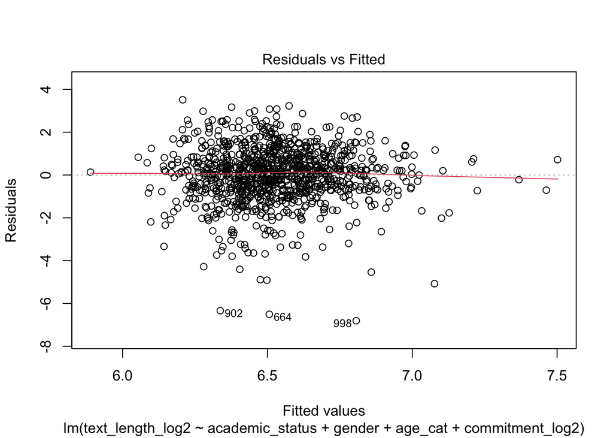

```r
# Plotting residuals vs. fitted values
plot(model_text_length, which = 1)
```

*Q-Q Plots for Normality of Residuals*

Q-Q (quantile-quantile) plot to assess whether the residuals follow a normal distribution

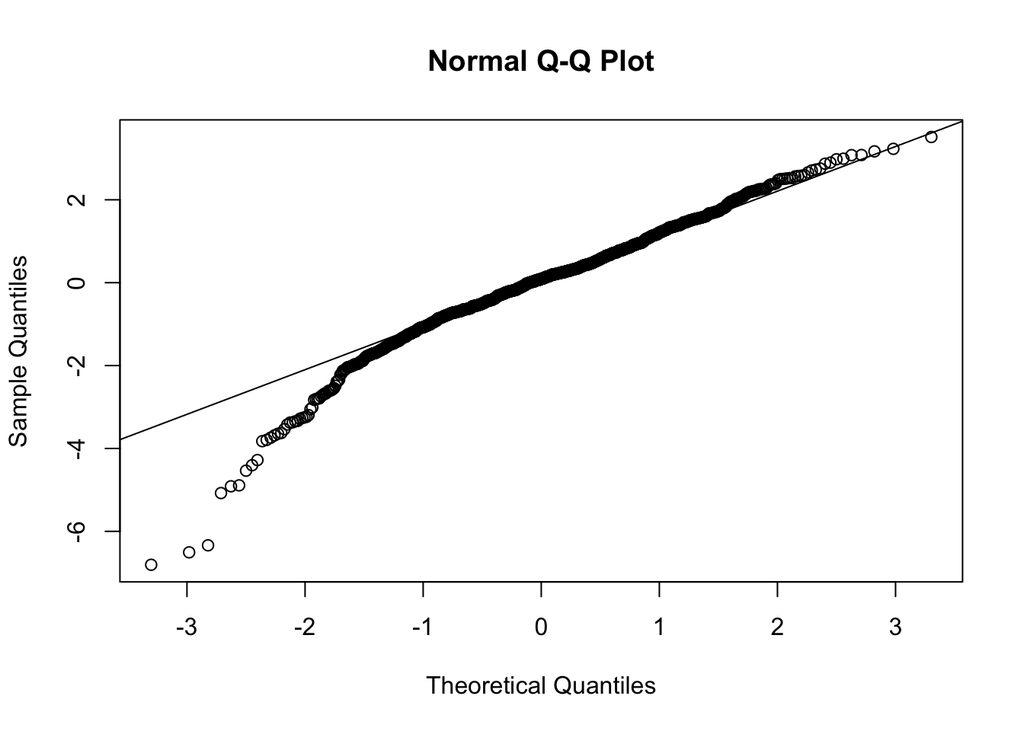

```r
# Q-Q plot
qqnorm(residuals(model_text_length))
qqline(residuals(model_text_length))
```

*Variance Inflation Factor (VIF) for Multicollinearity*

Assesses how much the variance of a coefficient is inflated due to multicollinearity in the model. VIF values above 5 or 10 indicate high multicollinearity that could be problematic.

```r
library(car)
vif(model_text_length)
```

```
##                     GVIF Df GVIF^(1/(2*Df))
## academic_status 1.012662  1        1.006311
## gender          1.009913  1        1.004944
## age_cat         1.033354  3        1.005483
## commitment_log2 1.030360  1        1.015067
```

## 2.2 Readability

```r
# Linear regression model with all controls
model_readability <- lm(readability_score ~ academic_status + gender + age_cat + commitment_log2, data = data)

summary(model_readability)
```

```
##
## Call:
## lm(formula = readability_score ~ academic_status + gender + age_cat +
##     commitment_log2, data = data)
##
## Residuals:
##      Min       1Q   Median       3Q      Max
## -18.4317  -3.2674  -0.0686   3.1082  21.7831
##
## Coefficients:
##                             Estimate Std. Error t value Pr(>|t|)
## (Intercept)                   9.4487     0.9867   9.576  < 2e-16 ***
## academic_statusnon-academic  -0.7058     0.3383  -2.086  0.03721 *
## genderFemale                  0.4982     0.3533   1.410  0.15877
## age_cat30-49                  0.1056     0.4639   0.228  0.81993
## age_cat50-69                 -0.6091     0.4725  -1.289  0.19760
## age_cat70+                   -2.2457     0.7936  -2.830  0.00475 **
## commitment_log2               0.7486     0.2768   2.705  0.00694 **
## ---
## Signif. codes:  0 '***' 0.001 '**' 0.01 '*' 0.05 '.' 0.1 ' ' 1
##
## Residual standard error: 5.384 on 1039 degrees of freedom
##   (17 observations deleted due to missingness)
## Multiple R-squared:  0.02222,    Adjusted R-squared:  0.01657
## F-statistic: 3.935 on 6 and 1039 DF,  p-value: 0.000676
```

```r
stargazer(model_readability, type = "text")
```

```
##
## =======================================================
##                                 Dependent variable:
##                             ---------------------------
##                                  readability_score
## -------------------------------------------------------
## academic_statusnon-academic          -0.706**
##                                       (0.338)
##
## genderFemale                           0.498
##                                       (0.353)
##
## age_cat30-49                           0.106
##                                       (0.464)
##
## age_cat50-69                          -0.609
##                                       (0.472)
##
## age_cat70+                           -2.246***
##                                       (0.794)
##
## commitment_log2                      0.749***
##                                       (0.277)
##
## Constant                             9.449***
##                                       (0.987)
##
## -------------------------------------------------------
## Observations                           1,046
## R2                                     0.022
## Adjusted R2                            0.017
## Residual Std. Error              5.384 (df = 1039)
## F Statistic                   3.935*** (df = 6; 1039)
## =======================================================
## Note:                       *p<0.1; **p<0.05; ***p<0.01
```

*Residuals Plot for Homoscedasticity and Linearity*

check if the residuals (differences between observed and predicted values) display constant variance across all levels of the predicted values (homoscedasticity) and if the relationship between the predictors and the outcome is linear.

**Homoscedasticity**: The spread of residuals should be roughly constant across all fitted values.

**Linearity**: The residuals should be randomly dispersed around the horizontal axis, without any systematic shape.

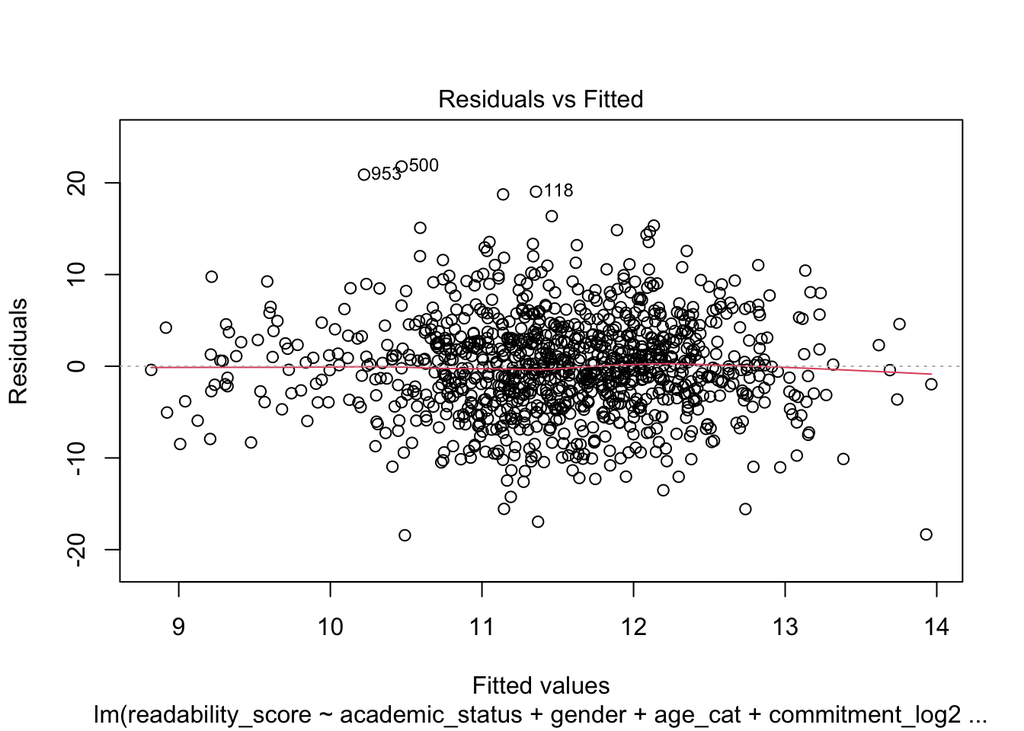

```r
# Plotting residuals vs. fitted values
plot(model_readability, which = 1)
```

*Q-Q Plots for Normality of Residuals*

Q-Q (quantile-quantile) plot to assess whether the residuals follow a normal distribution

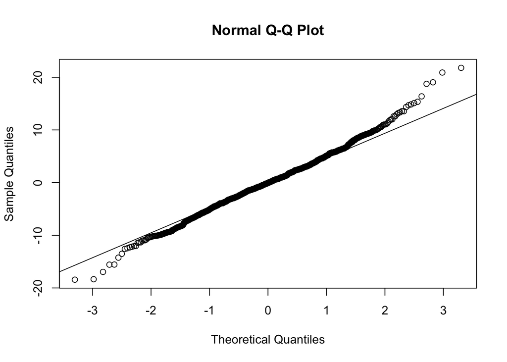

```r
# Q-Q plot
qqnorm(residuals(model_readability))
qqline(residuals(model_readability))
```

*Variance Inflation Factor (VIF) for Multicollinearity*

Assesses how much the variance of a coefficient is inflated due to multicollinearity in the model. VIF values above 5 or 10 indicate high multicollinearity that could be problematic.

```r
library(car)

vif(model_readability)
```

```
##                     GVIF Df GVIF^(1/(2*Df))
## academic_status 1.012662  1        1.006311
## gender          1.009913  1        1.004944
## age_cat         1.033354  3        1.005483
## commitment_log2 1.030360  1        1.015067
```

## 2.3 Predictability of Political Orientation

```r
# Linear regression model with all controls
model_leftright_pred_error <- lm(leftright_pred_error ~ academic_status + gender + age_cat + commitment_log2, data = data)

summary(model_leftright_pred_error)
```

```
##
## Call:
## lm(formula = leftright_pred_error ~ academic_status + gender +
##     age_cat + commitment_log2, data = data)
##
## Residuals:
##     Min      1Q  Median      3Q     Max
## -2.4184 -1.3230 -0.4378  1.0312  7.8306
##
## Coefficients:
##                             Estimate Std. Error t value Pr(>|t|)
## (Intercept)                  1.38144    0.35799   3.859 0.000123 ***
## academic_statusnon-academic  0.01993    0.12151   0.164 0.869746
## genderFemale                 0.03721    0.12762   0.292 0.770665
## age_cat30-49                -0.11977    0.16405  -0.730 0.465554
## age_cat50-69                -0.11081    0.16884  -0.656 0.511799
## age_cat70+                  -0.11969    0.28490  -0.420 0.674522
## commitment_log2              0.24888    0.10176   2.446 0.014661 *
## ---
## Signif. codes:  0 '***' 0.001 '**' 0.01 '*' 0.05 '.' 0.1 ' ' 1
##
## Residual standard error: 1.722 on 822 degrees of freedom
##   (234 observations deleted due to missingness)
## Multiple R-squared:  0.008037,   Adjusted R-squared:  0.0007959
## F-statistic:  1.11 on 6 and 822 DF,  p-value: 0.3545
```

```r
stargazer(model_leftright_pred_error, type = "text")
```

```
##
## =======================================================
##                                 Dependent variable:
##                             ---------------------------
##                                leftright_pred_error
## -------------------------------------------------------
## academic_statusnon-academic            0.020
##                                       (0.122)
##
## genderFemale                           0.037
##                                       (0.128)
##
## age_cat30-49                          -0.120
##                                       (0.164)
##
## age_cat50-69                          -0.111
##                                       (0.169)
##
## age_cat70+                            -0.120
##                                       (0.285)
##
## commitment_log2                       0.249**
##                                       (0.102)
##
## Constant                             1.381***
##                                       (0.358)
##
## -------------------------------------------------------
## Observations                            829
## R2                                     0.008
## Adjusted R2                            0.001
## Residual Std. Error              1.722 (df = 822)
## F Statistic                     1.110 (df = 6; 822)
## =======================================================
## Note:                       *p<0.1; **p<0.05; ***p<0.01
```

*Residuals Plot for Homoscedasticity and Linearity*

check if the residuals (differences between observed and predicted values) display constant variance across all levels of the predicted values (homoscedasticity) and if the relationship between the predictors and the outcome is linear.

**Homoscedasticity**: The spread of residuals should be roughly constant across all fitted values.

**Linearity**: The residuals should be randomly dispersed around the horizontal axis, without any systematic shape.

[figure not shown]

```r
# Plotting residuals vs. fitted values
plot(model_text_length, which = 1)
```

*Q-Q Plots for Normality of Residuals*

Q-Q (quantile-quantile) plot to assess whether the residuals follow a normal distribution

[figure not shown]

```r
# Q-Q plot
qqnorm(residuals(model_text_length))
qqline(residuals(model_text_length))
```

*Variance Inflation Factor (VIF) for Multicollinearity*

Assesses how much the variance of a coefficient is inflated due to multicollinearity in the model. VIF values above 5 or 10 indicate high multicollinearity that could be problematic.

```r
library(car)

vif(model_text_length)
```

```
##                     GVIF Df GVIF^(1/(2*Df))
## academic_status 1.012662  1        1.006311
## gender          1.009913  1        1.004944
## age_cat         1.033354  3        1.005483
## commitment_log2 1.030360  1        1.015067
```

## 2.4 Cluster (multinomial logistic regression)

```r
library(nnet)

# Fit multinomial logistic regression model
model_cluster <- multinom(cluster ~ academic_status + gender + age_cat + commitment_log2, data = data)
summary(model_cluster)
```

```
## Call:
## multinom(formula = cluster ~ academic_status + gender + age_cat +
##     commitment_log2, data = data)
##
## Coefficients:
##                    (Intercept) academic_statusnon-academic genderFemale
## Harms-based         0.18868448                   0.4973202   0.07812718
## Denying/Nonsense    0.05688283                   0.4426438  -0.62611212
## Harms-based narrow -0.53295662                   0.0486854   0.14795133
##                    age_cat30-49 age_cat50-69  age_cat70+ commitment_log2
## Harms-based           0.3452087    0.5544931  0.71108435     -0.17271798
## Denying/Nonsense      0.4197440    0.8478711  0.72629070     -0.33049594
## Harms-based narrow    0.1382780    0.3381772 -0.07683886     -0.03941902
##
## Std. Errors:
##                    (Intercept) academic_statusnon-academic genderFemale
## Harms-based          0.4605207                   0.1600620    0.1642388
## Denying/Nonsense     0.5764821                   0.1951362    0.2202212
## Harms-based narrow   0.5354985                   0.1911782    0.1909668
##                    age_cat30-49 age_cat50-69 age_cat70+ commitment_log2
## Harms-based           0.2134601    0.2212634  0.3668210       0.1294180
## Denying/Nonsense      0.2760915    0.2790073  0.4601335       0.1631689
## Harms-based narrow    0.2465348    0.2545674  0.4795934       0.1501799
##
## Residual Deviance: 2759.524
## AIC: 2801.524
```

```r
stargazer(model_cluster, type = "text")
```

```
##
## ===========================================================================
##                                           Dependent variable:
##                             -----------------------------------------------
##                             Harms-based Denying/Nonsense Harms-based narrow
##                                 (1)           (2)               (3)
## ---------------------------------------------------------------------------
## academic_statusnon-academic  0.497***       0.443**            0.049
##                               (0.160)       (0.195)           (0.191)
##
## genderFemale                   0.078       -0.626***           0.148
##                               (0.164)       (0.220)           (0.191)
##
## age_cat30-49                   0.345         0.420             0.138
##                               (0.213)       (0.276)           (0.247)
##
## age_cat50-69                  0.554**       0.848***           0.338
##                               (0.221)       (0.279)           (0.255)
##
## age_cat70+                    0.711*         0.726             -0.077
##                               (0.367)       (0.460)           (0.480)
##
## commitment_log2               -0.173        -0.330**           -0.039
##                               (0.129)       (0.163)           (0.150)
##
## Constant                       0.189         0.057             -0.533
##                               (0.461)       (0.576)           (0.535)
##
## ---------------------------------------------------------------------------
## Akaike Inf. Crit.            2,801.524     2,801.524         2,801.524
## ===========================================================================
## Note:                                           *p<0.1; **p<0.05; ***p<0.01
```

## 2.5 Create Table

```r
stargazer(model_text_length, model_readability, model_leftright_pred_error, type = "text")
```

```
##
## ================================================================================================
##                                                     Dependent variable:
##                             --------------------------------------------------------------------
##                                text_length_log2        readability_score    leftright_pred_error
##                                       (1)                     (2)                   (3)
## ------------------------------------------------------------------------------------------------
## academic_statusnon-academic         -0.016                 -0.706**                0.020
##                                     (0.081)                 (0.338)               (0.122)
##
## genderFemale                        -0.001                   0.498                 0.037
##                                     (0.085)                 (0.353)               (0.128)
##
## age_cat30-49                        -0.172                   0.106                 -0.120
##                                     (0.111)                 (0.464)               (0.164)
##
## age_cat50-69                        -0.192*                 -0.609                 -0.111
##                                     (0.113)                 (0.472)               (0.169)
##
## age_cat70+                          -0.268                 -2.246***               -0.120
##                                     (0.191)                 (0.794)               (0.285)
##
## commitment_log2                    0.311***                0.749***               0.249**
##                                     (0.066)                 (0.277)               (0.102)
##
## Constant                           5.638***                9.449***               1.381***
##                                     (0.237)                 (0.987)               (0.358)
##
## ------------------------------------------------------------------------------------------------
## Observations                         1,046                   1,046                  829
## R2                                   0.022                   0.022                 0.008
## Adjusted R2                          0.017                   0.017                 0.001
## Residual Std. Error            1.292 (df = 1039)       5.384 (df = 1039)      1.722 (df = 822)
## F Statistic                 3.973*** (df = 6; 1039) 3.935*** (df = 6; 1039) 1.110 (df = 6; 822)
## ================================================================================================
## Note:                                                                *p<0.1; **p<0.05; ***p<0.01
```